# Carbon stocks analysis

Lydia White

2025-05-24

## Set up our environment

### Load libraries

First we load libraries (which you should already have installed)

```r
library(tidyverse)
library(googlesheets4)
```

### Import data

```r
# this function allows you to reads public google sheets without having to log in
gs4_deauth()

# import carbon_stocks_m2 sheet

#stocks <- read_sheet("1AyJXPaJZMl1a4vogToBIMSoPDGY2wBq8K3k8g9EptRc", sheet = "carbon_stocks_m2") #2025

stocks <- read_sheet("1STH7IQobfCN5dumGnuSGqDiIoqHk1IkAUg3TTRu0pVc", sheet = "carbon_stocks_m2") #2023
```

## Visualise carbon stocks with boxplots

```r
# convert site column from numerical to characters
stocks <- stocks %>%
  mutate(site = as.character(site))
```

Lets now visualise differences in carbon stocks with boxplots, which illustrate the median value and the spread of the second and third quartile. The lower and upper quartiles are shown as horizontal lines either side of the rectangle.

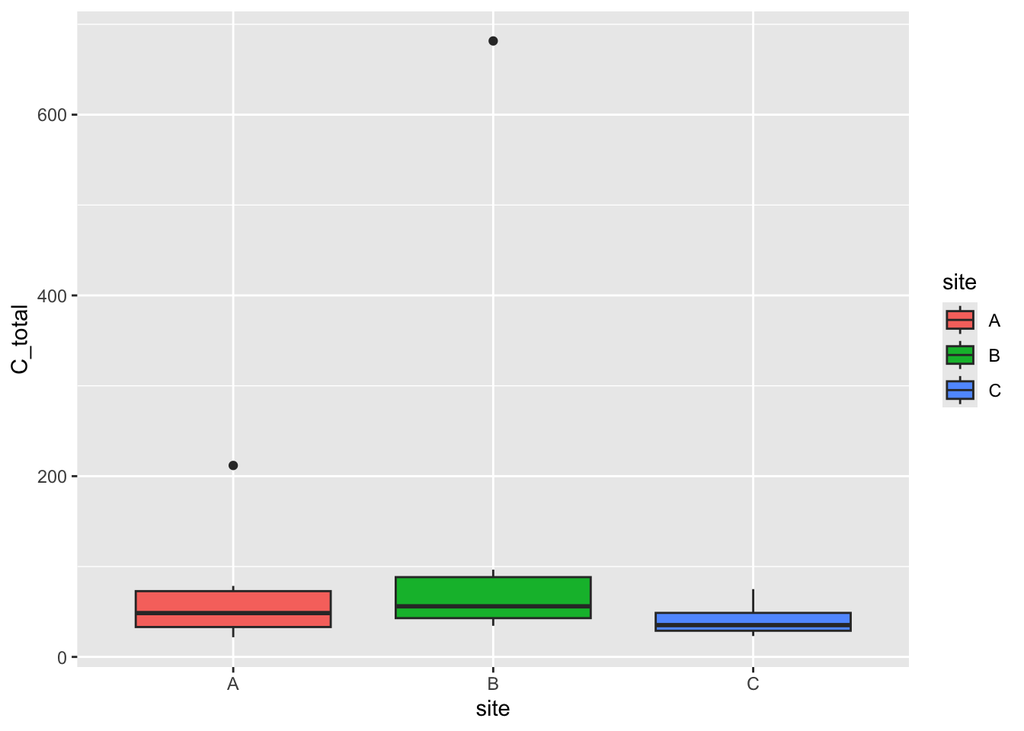

```r
ggplot(stocks, aes(x = site, y = C_total, fill = site)) +
  geom_boxplot()
```

We can make less work for ourselves and plot all the data at once, but we have to reformat the data into long format first.

```r
stocks_long <- stocks %>%
  pivot_longer(cols = starts_with("C"), names_to = "compartment", values_to = "carbon_stock")
```

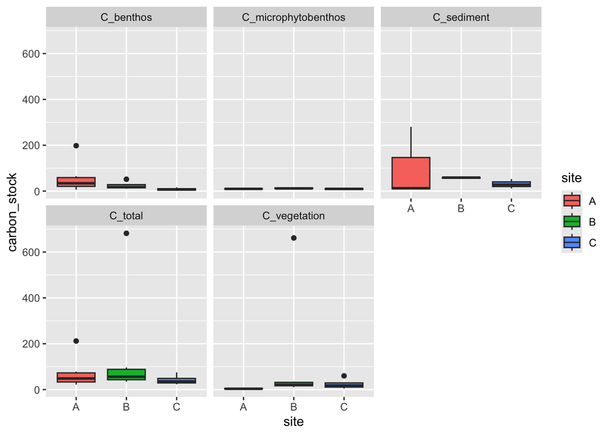

```r
ggplot(stocks_long, aes(x = site, y = carbon_stock, fill = site)) +
  geom_boxplot() +
  facet_wrap(~ compartment)
```

We can tidy up the plot a bit, we **1)** edit the order of the plots, **2)** edit the y axis label, **3)** remove the legend and **4)** make the axis scale easier to interpret

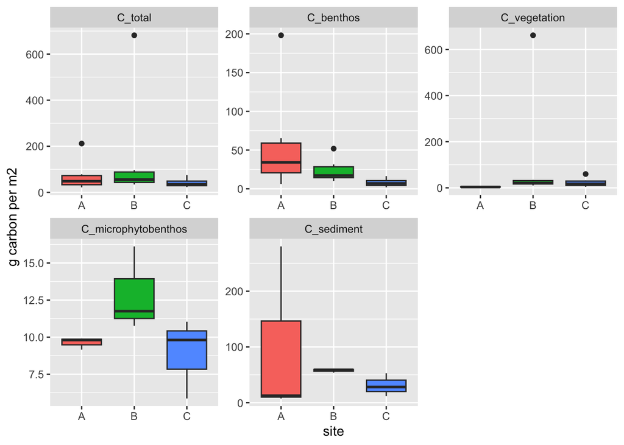

```r
compartment_order <- c("C_total", "C_benthos", "C_vegetation",
                       "C_microphytobenthos", "C_sediment")

ggplot(stocks_long, aes(x = site, y = carbon_stock, fill = site)) +
  geom_boxplot() +
  facet_wrap(~ factor(compartment, levels = compartment_order), scales = "free") +
  ylab("g carbon per m2") +
  theme(legend.position = "none")
```

## Test differences with models

Let’s explore these differences with statistical models, we can use one-way ANOVA to test if carbon stocks significantly differ between sites

```r
anova1 <- aov(C_total ~ site, data = stocks)
summary(anova1)
```

```
##             Df Sum Sq Mean Sq F value Pr(>F)
## site         2  45968   22984   0.972  0.401
## Residuals   15 354667   23644
```

### Checking assumptions of your model

The ANOVA test assumes that, the residuals from the model are normally distributed and the variance across groups are homogeneous (i.e. similar). We can check that with some diagnostic plots.

#### Homogeneity of variances

The residuals versus fits plot can be used to check the homogeneity of variances, the line. shoud be approximately straight For more information about diagnostic plots for `lm` objects type `?plot.lm` in your console. As you can read in the documentation of the function, `1` is for “Residuals vs Fitted”, aka ‘Tukey-Anscombe’ plot

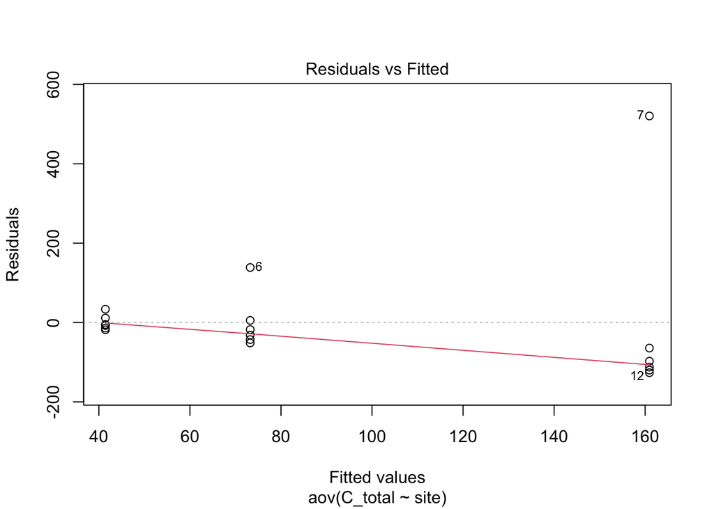

```r
plot(anova1, which = 1)
```

It’s also possible to use Levene’s test to check the homogeneity of variances. p < 0.05 means that they are not homogeneous. `car::` allows you to use a function from `car` without loading all the library.

```r
car::leveneTest(C_total ~ site, data = stocks)
```

```
## Levene's Test for Homogeneity of Variance (center = median)
##       Df F value Pr(>F)
## group  2  0.8311 0.4547
##       15
```

#### Normally distributed residuals

The normal probability plot of residuals is used to check the assumption that the residuals are normally distributed. It should approximately follow a straight line.

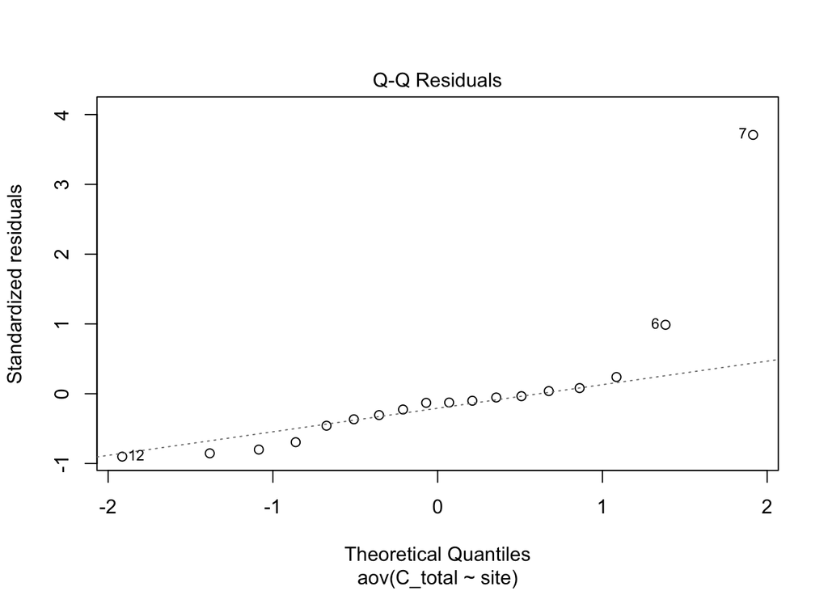

```r
plot(anova1, which = 2)
```

It’s also possible to use shapiro wilk test to check if the residuals are normally distributed. p < 0.05 means that they are not normally distributed.

```r
my_residuals <- rstandard(anova1)
shapiro.test(my_residuals)
```

```
##
##  Shapiro-Wilk normality test
##
## data:  my_residuals
## W = 0.64983, p-value = 2.204e-05
```

In one-way ANOVA test, a significant p-value indicates that some of the group means are different, but we don’t know which pairs of groups are different. It’s possible to perform multiple pairwise-comparison, to determine if the mean difference between specific pairs of group are statistically significant.

```r
TukeyHSD(anova1)
```

```
##   Tukey multiple comparisons of means
##     95% family-wise confidence level
##
## Fit: aov(formula = C_total ~ site, data = stocks)
##
## $site
##           diff       lwr      upr     p adj
## B-A   87.69453 -142.9030 318.2921 0.5954366
## C-A  -31.81174 -262.4093 198.7858 0.9319859
## C-B -119.50628 -350.1038 111.0913 0.3927487
```

### What if assumptions are not met?

Note that, a non-parametric alternative to one-way ANOVA is Kruskal-Wallis rank sum test, which can be used when ANOVA assumptions are not met.

```r
kruskal.test(C_total ~ site, data = stocks)
```

```
##
##  Kruskal-Wallis rank sum test
##
## data:  C_total by site
## Kruskal-Wallis chi-squared = 2.4678, df = 2, p-value = 0.2911
```

## Compare compartment carbon stocks between sites

You could also carry out ANOVAs on the different compartments to see if fauna, vegetation, sediment or microphytobenthos carbon stocks differ between sites.

```r
# write scripts here (copy and paste from above and change variable names)
```